# Model assumptions

## Link into the module

- Statistical modelling I: Interpret the results of statistical models (*t*-test, *ANOVA*, linear regression) in the context of the data
- Statistical modelling II: Justify a decision to use a particular statsitical test given a dataset
- Statistical inference I: Describe the role of classical statistical inference in terms of the population and the sample

## Learning outcomes

### After completing this lecture and the workshop you should be able to

- name the properties of the normal distribution
- explain the core assumptions of parametric tests
- describe the essence of the central limit theorem

## Model assumptions

### “All models are wrong, but some are useful.” – George Box

## Model assumptions

### Why do we care?

- Models are approximations of reality by reducing the complexity.
- All models are wrong, but some are useful.
- But models are machines that respond to input; they will always give some results.
- Statistical models make assumptions about the input.
- Accuracy of the results depends on the correspondance between input (data) and assumptions.
- All parametric models make the same assumptions.
- Non-parametric models do not: e.g. Chi-squared [\(\chi^2\)] test, Mann Whitney U test, Spearman’s rank correlation

[figure not shown]

## What is a parametric model?

- A family of probability distributions with a finite number of parameters.
- E.g. normal distribution has two parameters: mean and standard devition
- Normal distribution is entailed in *t*-test, ANOVA, linear regression

## What do parametric models assume?

- Normal distribution is at the heart of parametrix models
- Interval / continous data
- Central limit theorem
- Observations are independent and identically distributed (iid)
  - See also lecture and workshop related to week 6
- Homogeneity of variance

## Properties of the normal distribution

### aka the “bell curve”

## Properties of the normal distribution

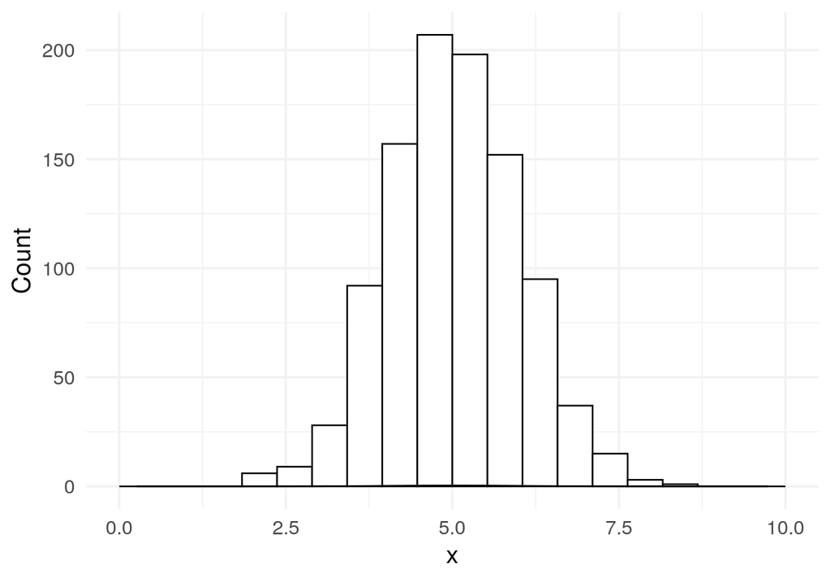

- Histogram shows counts / frequency of observations *x*.
- Density plot describes the relative likelihood of *x* taking on a certain value.

## Properties of the normal distribution

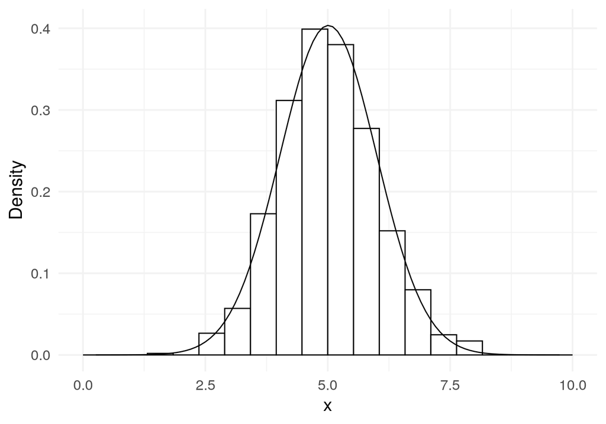

- Histogram shows counts / frequency of observations *x*.
- Density plot describes the relative likelihood of *x* taking on a certain value.

## Properties of the normal distribution

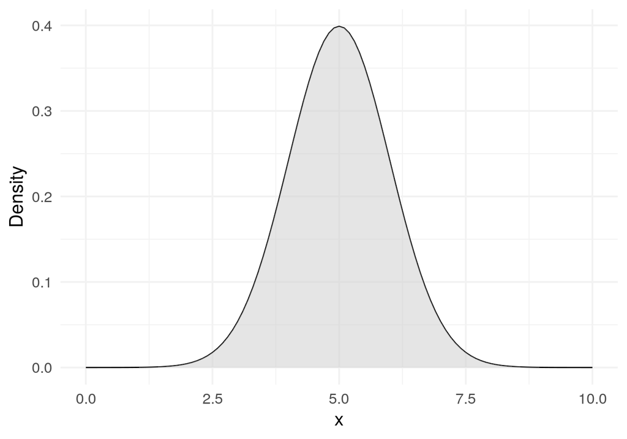

- Histogram shows counts / frequency of observations *x*.
- Density plot describes the relative likelihood of *x* taking on a certain value.

## Properties of the normal distribution

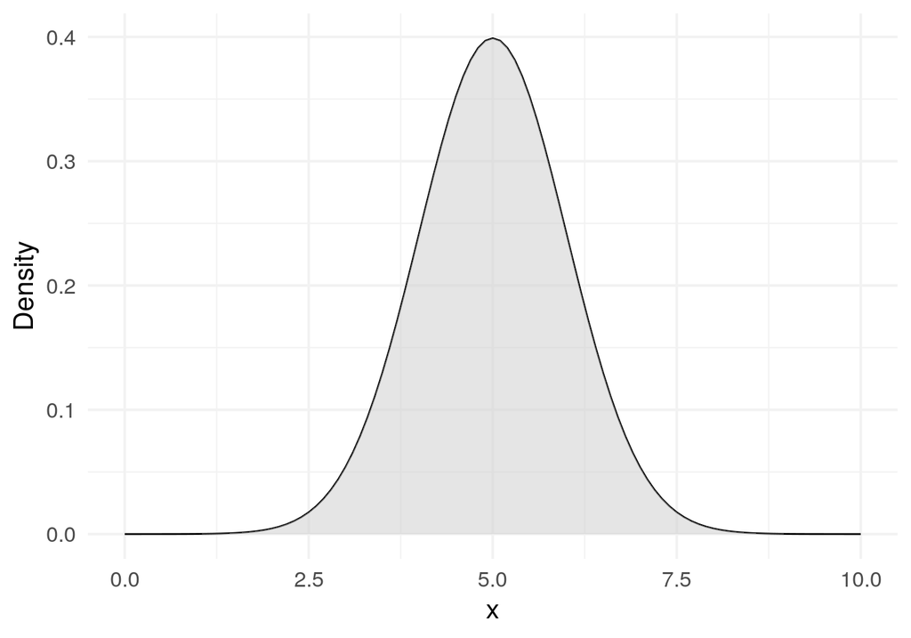

- Symmetrical

## Properties of the normal distribution

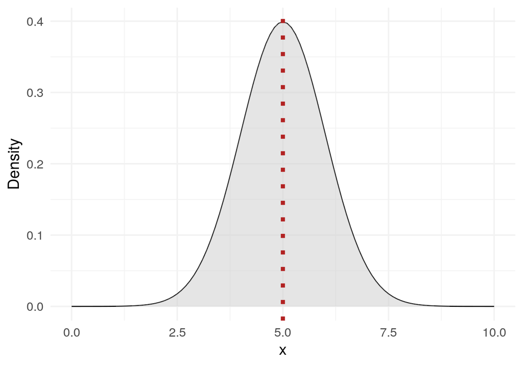

- **Symmetrical**
  - Mean = Mode = Median

## Properties of the normal distribution

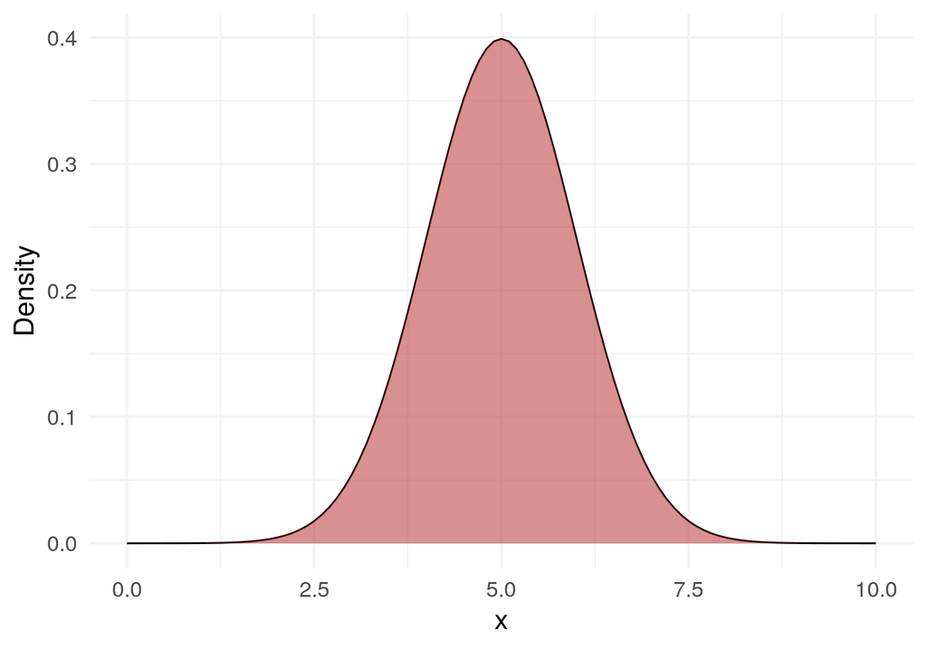

- Symmetrical
- **Area underneath the curve is 1**

## Properties of the normal distribution

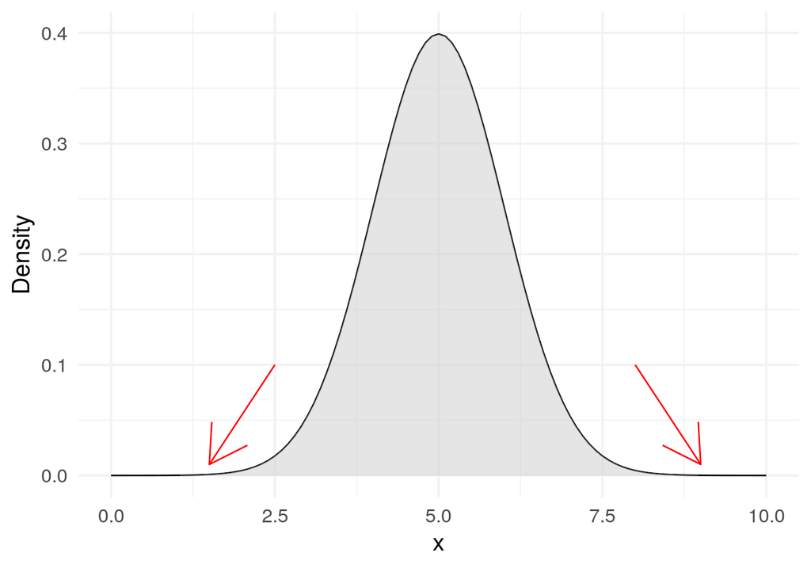

- Symmetrical
- Area underneath the curve is 1
- **Tails approach but never hit zero**

## Properties of the normal distribution

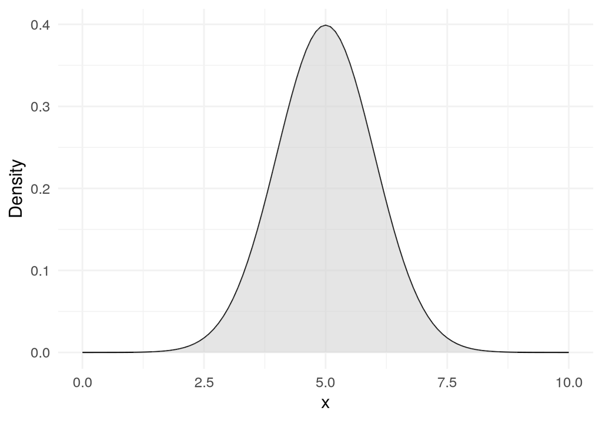

- Symmetrical
- Area underneath the curve is 1
- Tails approach but never hit zero
- **Characterised by mean and standard deviation**

## Properties of the normal distribution

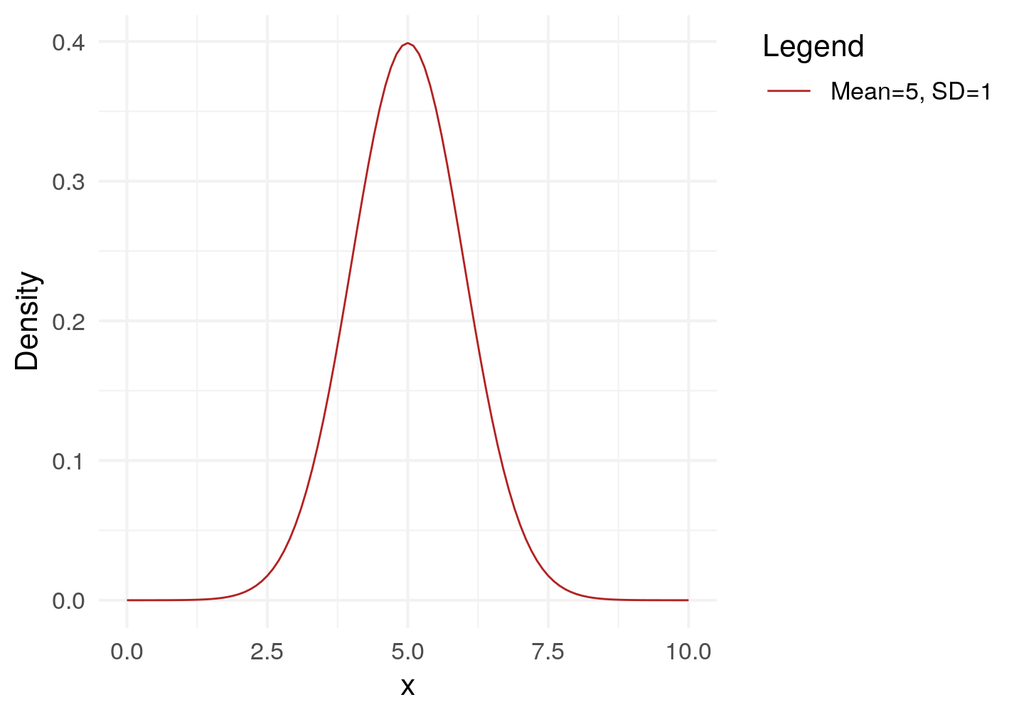

- Symmetrical
- Area underneath the curve is 1
- Tails approach but never hit zero
- **Characterised by mean and standard deviation**

## Properties of the normal distribution

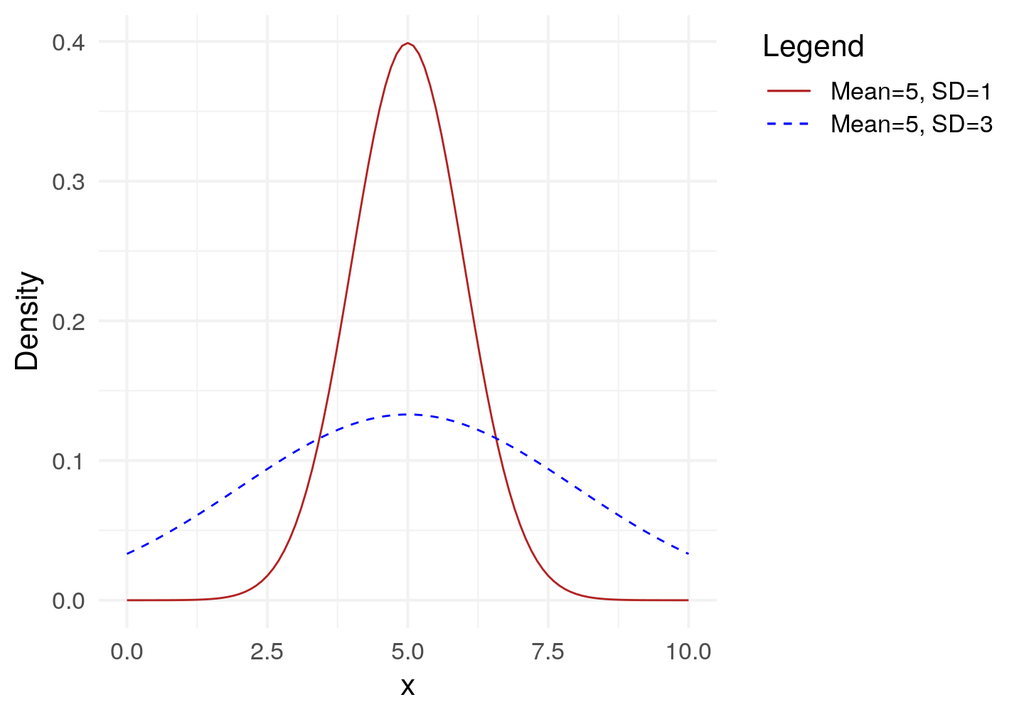

- Symmetrical
- Area underneath the curve is 1
- Tails approach but never hit zero
- **Characterised by mean and standard deviation**

## Properties of the normal distribution

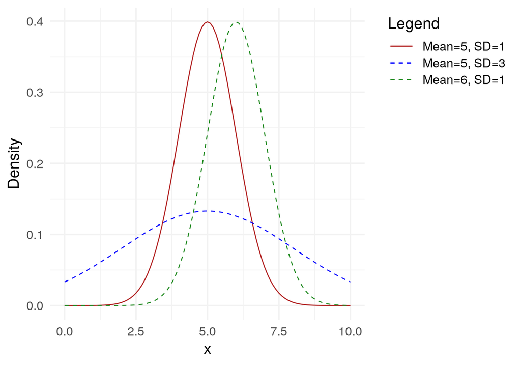

- Symmetrical
- Area underneath the curve is 1
- Tails approach but never hit zero
- **Characterised by mean and standard deviation**
  - Standard normal distribution: mean=0, SD=1

## Properties of the normal distribution

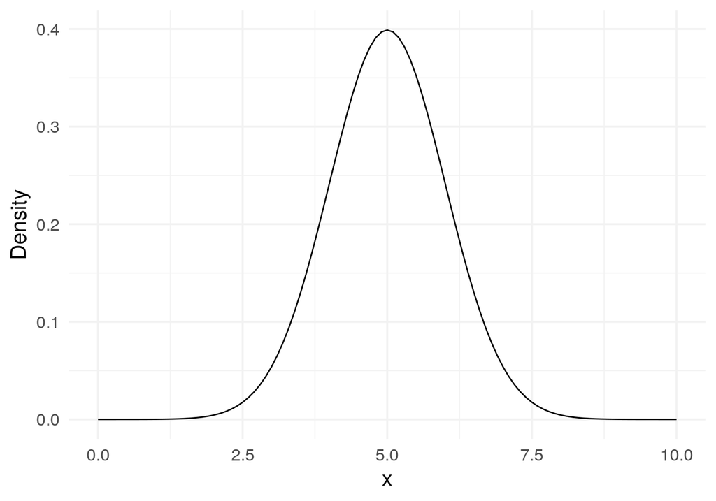

- Symmetrical
- Area underneath the curve is 1
- Tails approach but never hit zero
- Characterised by mean and standard deviation
- **Continuous**
  - Every value on y is defined for a value x

## Properties of the normal distribution

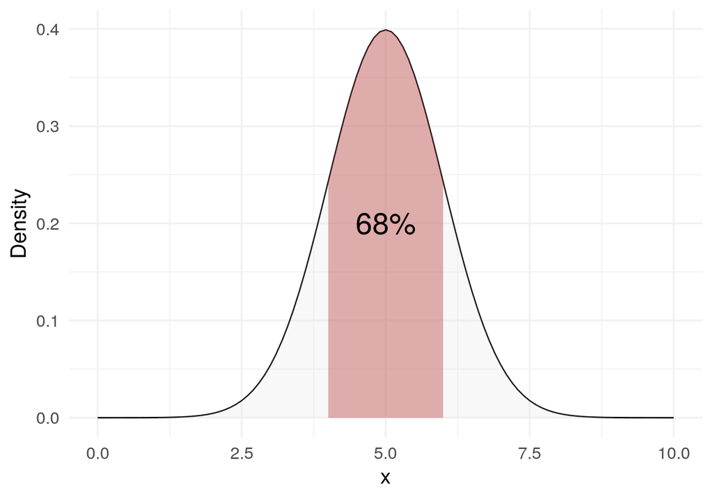

- Area underneath the curve is 1 (=100%)
- 68% within 1 SD

## Properties of the normal distribution

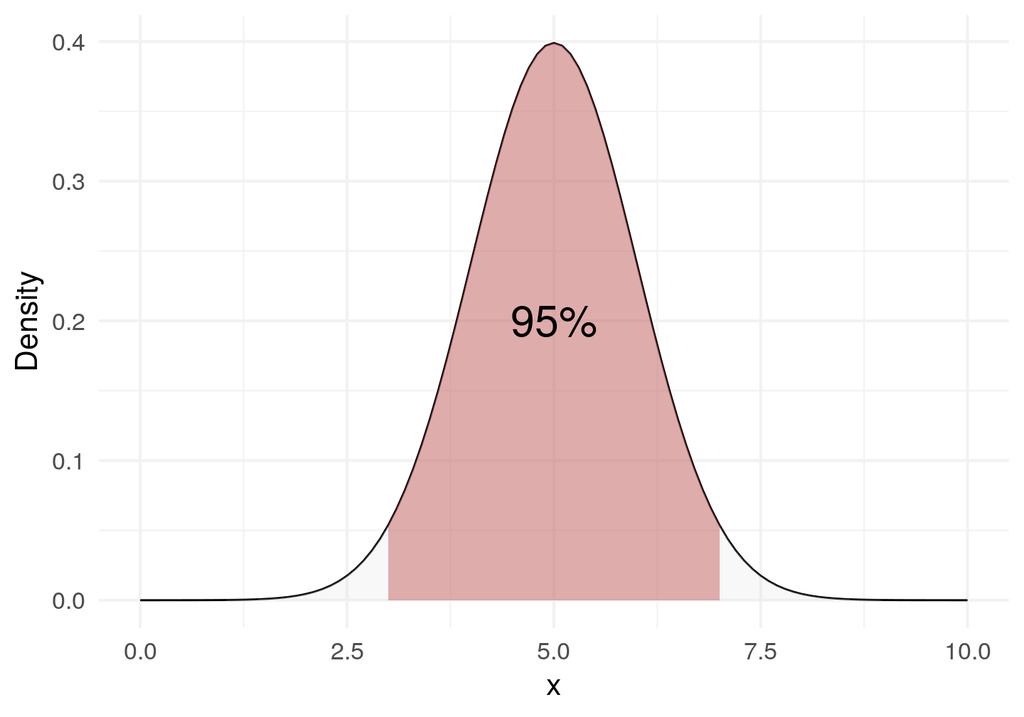

- Area underneath the curve is 1 (=100%)
- 68% within 1 SD
- 95% within 2 SDs

## Properties of the normal distribution

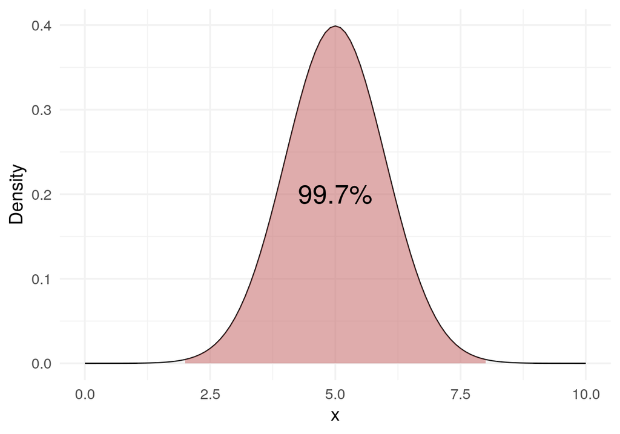

- Area underneath the curve is 1 (=100%)
- 68% within 1 SD
- 95% within 2 SDs
- 99.7% wihtin 3 SDs

## Properties of the normal distribution

- Continuous variable:
  - All values between negative and postive infinity are in principle possible.
  - All values between -Inf and +Inf are defined.
- Linearity assumption:
  - Distances between adjacent values must be the same, i.e. \(\pm 1\) on a linear scale.
  - Distances between 1 inch and 2 inch is 1 etc.

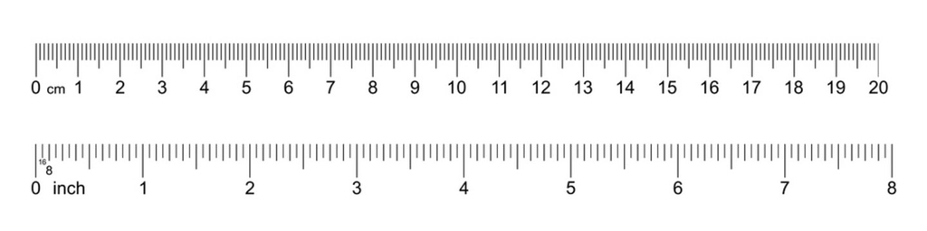

Here is a ruler.

## Properties of the normal distribution

- Not continuous but discrete categories:
  - binary outcomes, count data, ordinal, psychometric scales

## Properties of the normal distribution

- Non linear:
  - Logarithmic scale
  - Distance between units is \(\cdot\) or \(\div\) 10: 0.1, 1, 10, 100
  - Used to gain granularity on lower end of a scale but also include large numbers
  - In psychology log-transformations are often used for distributions with right skew (e.g. reaction times).

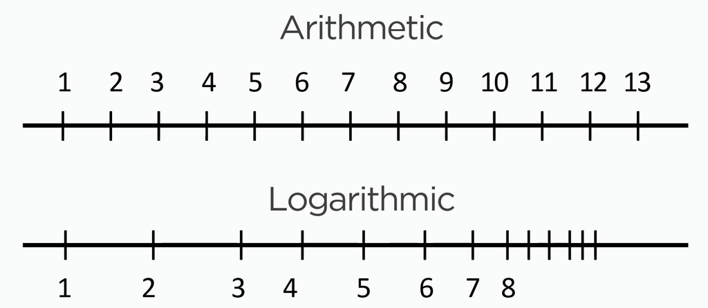

Linear vs logarithmic scale.

## Properties of the normal distribution

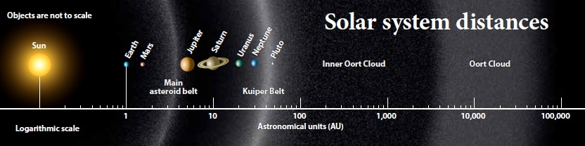

Astronomy: Roen Kelly

## Properties of the normal distribution

- Physiological and psychological development could be better represented on a log scale.

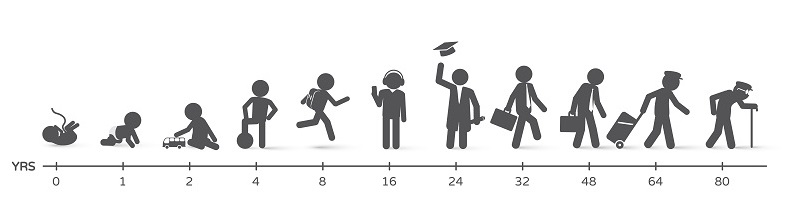

Life span

## Properties of the normal distribution

- Psychometric scales are neither continuous nor linear (see intro of Bürkner and Vuorre 2019).
- Response categories
  - ordinal
  - limited response options
  - implicit order
  - not equidistant
- We will see later why the use of linear models is not unjustified for psychometric data.
- For a full discussion see Liddell and Kruschke (2018)

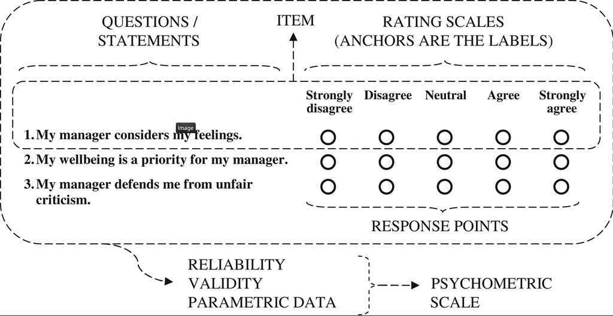

Psychometric scale; see Robinson (2018)

## Properties of the normal distribution

- Striclty speaking, most things are not continuous.
- Most variables have an upper and lower bound, e.g., people can’t be fast than 0 msecs or smaller than 0 inch.
- All observations are discrete in practice.
- A normal distribution is often suitable for practice considerations.

## Example: IQ

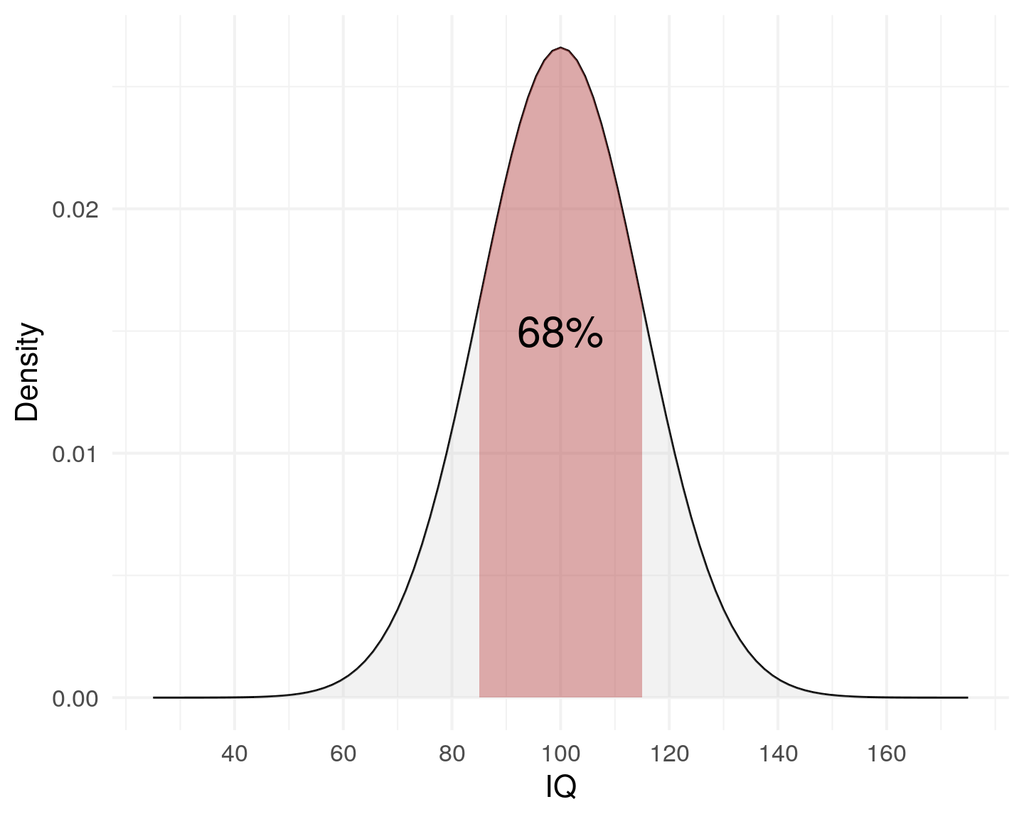

- Intelligence quotient: total score of standardised tests to assess human intelligence
- Population values are defined: mean = 100, SD = 15
- \(\sim\) 2/3 of the population scores between 85 and 115
- 2.5% \(>\) 130 (extremely high; gifted)
- 2.5% \(<\) 70 (extremely low; impaired)

## Example: IQ

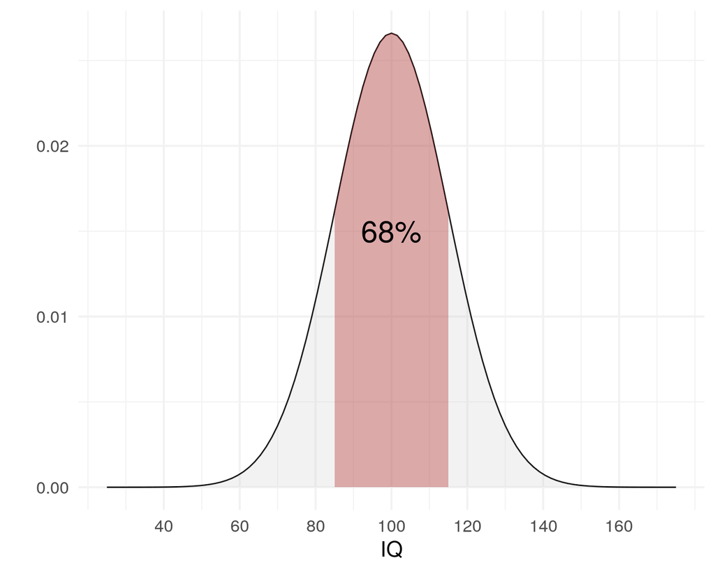

- Each person has individual unknown IQ value.
- IQ tests aim to estimate this quantity.
- Intelligence is abstract by nature and can’t be measured objectively unlike distance, mass, income

## Example: IQ

### Gill (2014), p. 85-86 (data from Lynn and Vanhanen 2001)

| Country | mean IQ |
| --- | --- |
| Hong Kong | 107 |
| Korea South | 106 |
| Japan | 105 |
| Taiwan | 104 |
| Singapore | 103 |
| Austria | 102 |
| Germany | 102 |
| Italy | 102 |

- Standard IQ test measure intelligence and reasoning (mean = 100, SD = 15)
- Economic and cultural biases
- Mean IQ scores from 80 countries; each value is a mean of totals (country mean of ppt totals)

## Example: IQ

### Gill (2014), p. 85-86 (data from Lynn and Vanhanen 2001)

| Country | mean IQ |
| --- | --- |
| Ethiopia | 63 |
| Sierra Leone | 64 |
| Congo Zaire | 65 |
| Guinea | 66 |
| Zimbabwe | 66 |
| Nigeria | 67 |
| Ghana | 71 |
| Jamaica | 72 |

- Standard IQ test measure intelligence and reasoning (mean = 100, SD = 15)
- Economic and cultural biases
- Mean IQ scores from 80 countries; each value is a mean of totals (country mean of ppt totals)

## Example: IQ

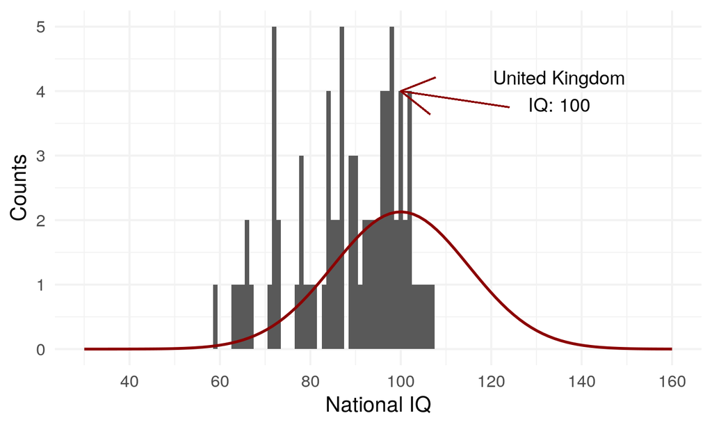

## Simulation

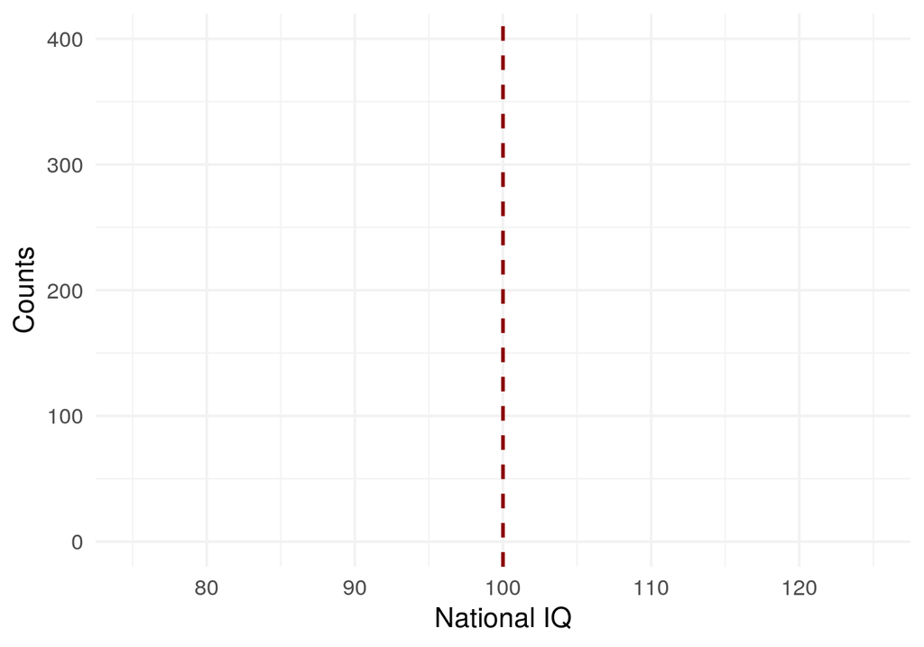

- Is there a econommic / cultural bias?
- Difficult to replicate this study
- So here is a quick simulation:
  - Redo this experiment 2,000 times
  - Sample 30 countries from data
  - Calculate sample mean across samples countries
  - Sampling distribution (week 6)
- We will see how this works later …

## Simulation

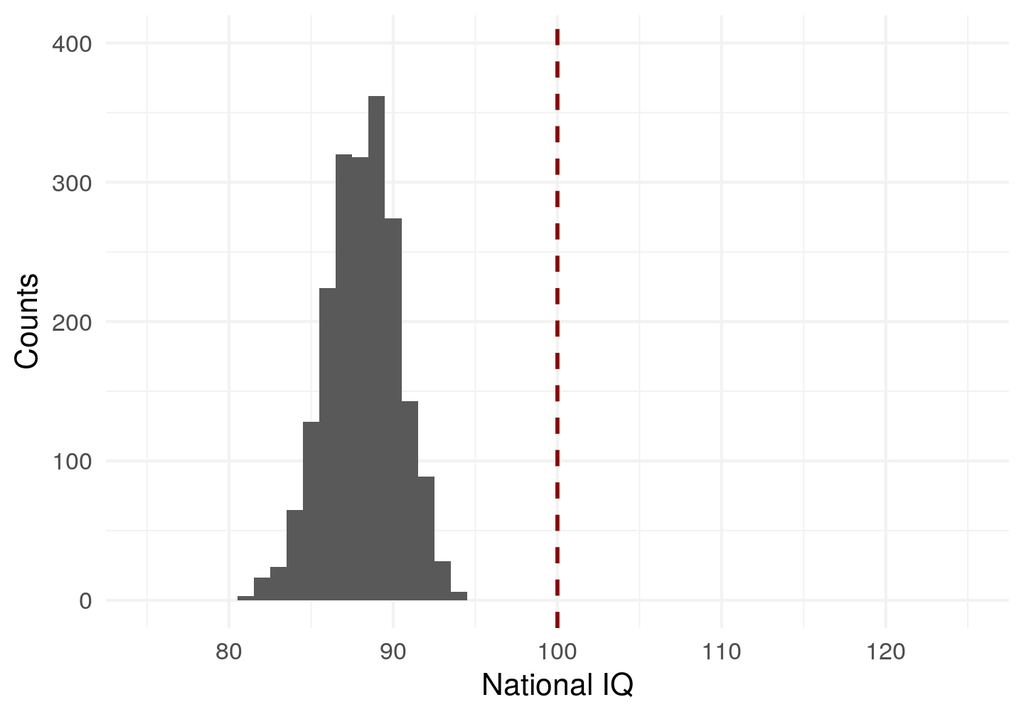

- Is there a econommic / cultural bias?
- Difficult to replicate this study
- So here is a quick simulation:
  - Redo this experiment 2,000 times
  - Sample 30 countries from data
  - Calculate sample mean across samples countries
  - Sampling distribution (week 6)
- We will see how this works later …

## Normal distribution

- We assume that the process that we sample data from is normal distributed.
- We **know** IQ is normal distributed but our example didn’t look normal at all.
- We will see in the following that the data don’t need to be normal distributed at all.
- Why do we bother with the normal distribution?
- Because of the central limit theorem.

## Central limit theorem (CLT)

## Central limit theorem (CLT)

- The sample mean will be approximately normally distributed for large sample sizes, regardless of the distribution from which we are sampling.
- We can often use statistical inference that are based on a normal distribution even if we are sampling from a population that is weird (i.e. not normal), if we ensure a large sample size.
- Covered in Week 6: mean of the sampling distribution is estimate of population mean
- Works for means (e.g. depression), totals (e.g. IQ), SDs, etc.

## Application of CLT

### a simulation

- CES-D scale: self-report depression (Radloff 1977)
- 22 items to assess the degree of depression
- 5-point Likert scale: Strongly disagree - Strongly agree
- Item 1: I was bothered by things that usually don’t bother me.
- Item 2: I had a poor appetite.
- Item 3: I did no feel like eating, even tohugh I should have been hungry.
- …
- Item 22: I didn’t enjoy life.

## Application of CLT

- The distribution of the sample approaches normality as the number of trials / participants increases.

```r
N_items = 22 # 22 items
response_options = 1:5 # 5-point Likert scale
(ppt_1 <- sample(response_options, N_items, replace = T))
```

```
 [1] 4 5 1 5 3 5 4 2 1 2 3 1 3 4 1 5 4 1 5 5 2 1
```

## Application of CLT

- Data are not normal: discrete values, range from 1-5, not symmetric
- Total of 22 items

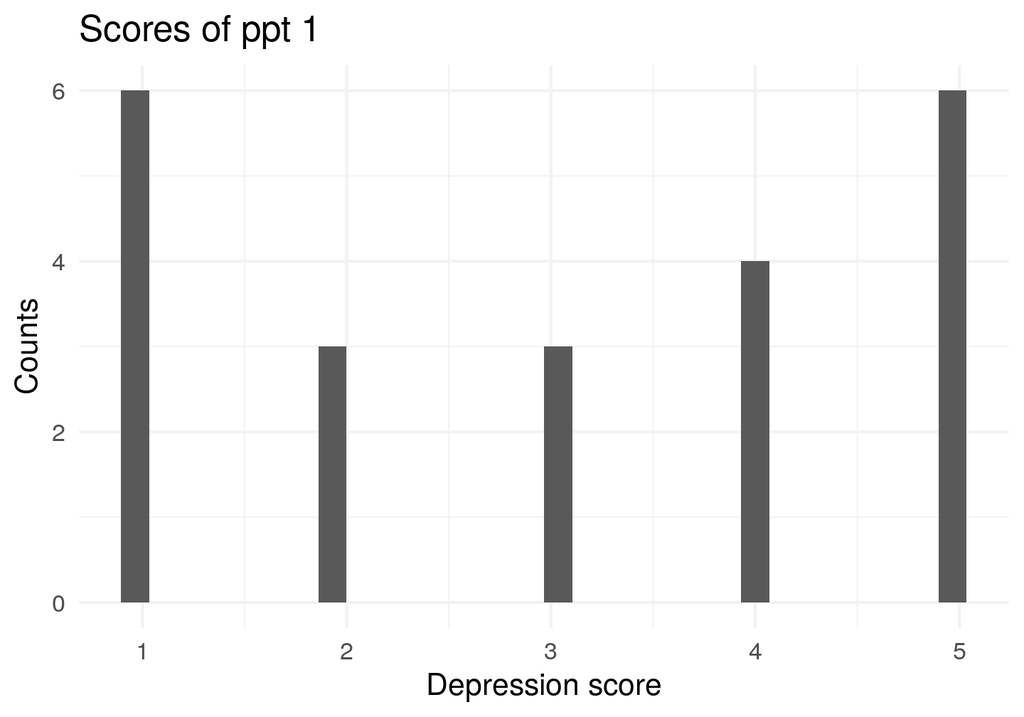

## Application of CLT

- Repeat for another ppt

```r
(ppt_2 <- sample(response_options, N_items, replace = T))
```

```
 [1] 2 2 1 1 1 5 1 5 1 3 2 5 1 3 3 1 1 1 5 2 2 2
```

## Application of CLT

```r
mean(ppt_1); mean(ppt_2)
```

```
[1] 3.045455
```

```
[1] 2.272727
```

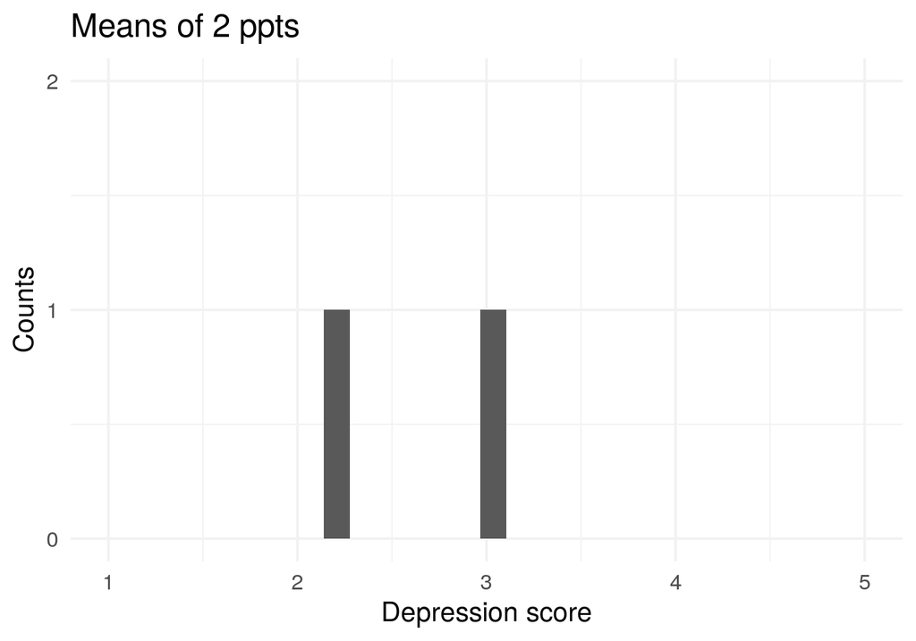

## Application of CLT

- Repeat for 10 ppts

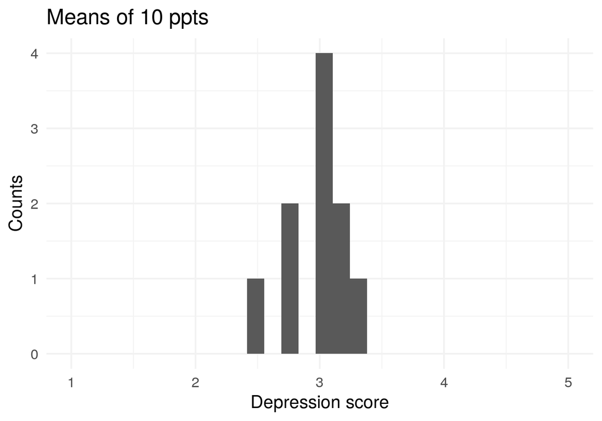

## Application of CLT

- Repeat for 100 ppts

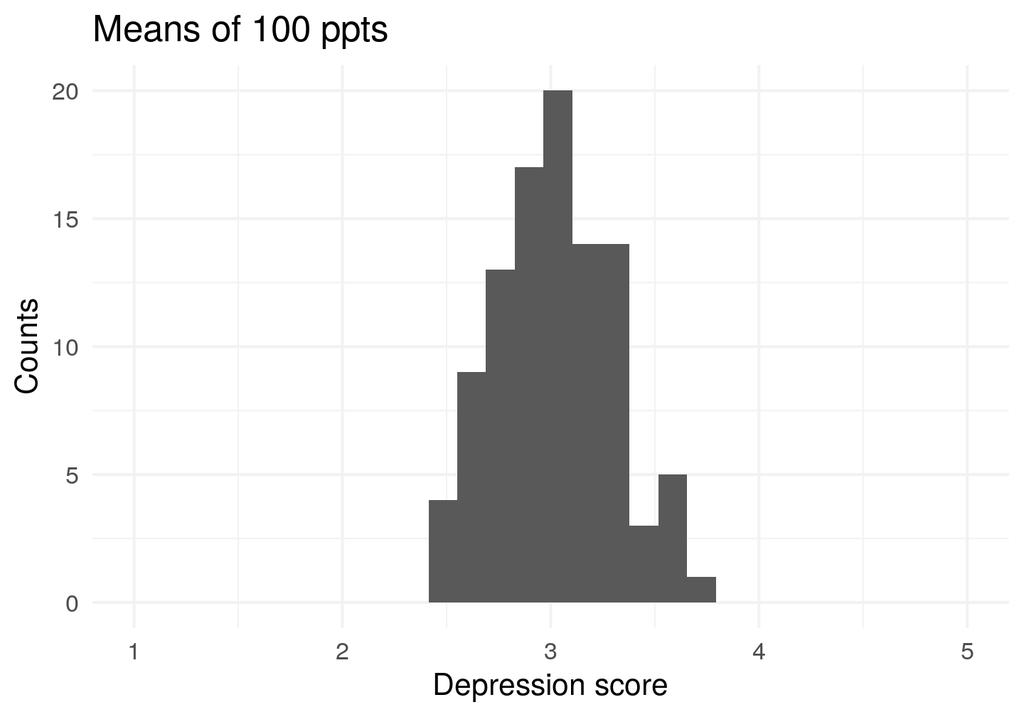

## Application of CLT

- Repeat for 1,000 ppts

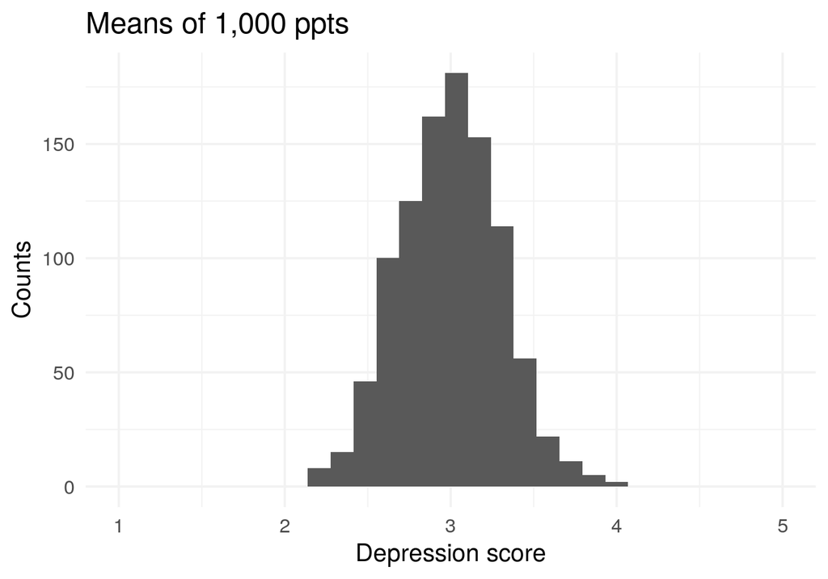

## Application of CLT

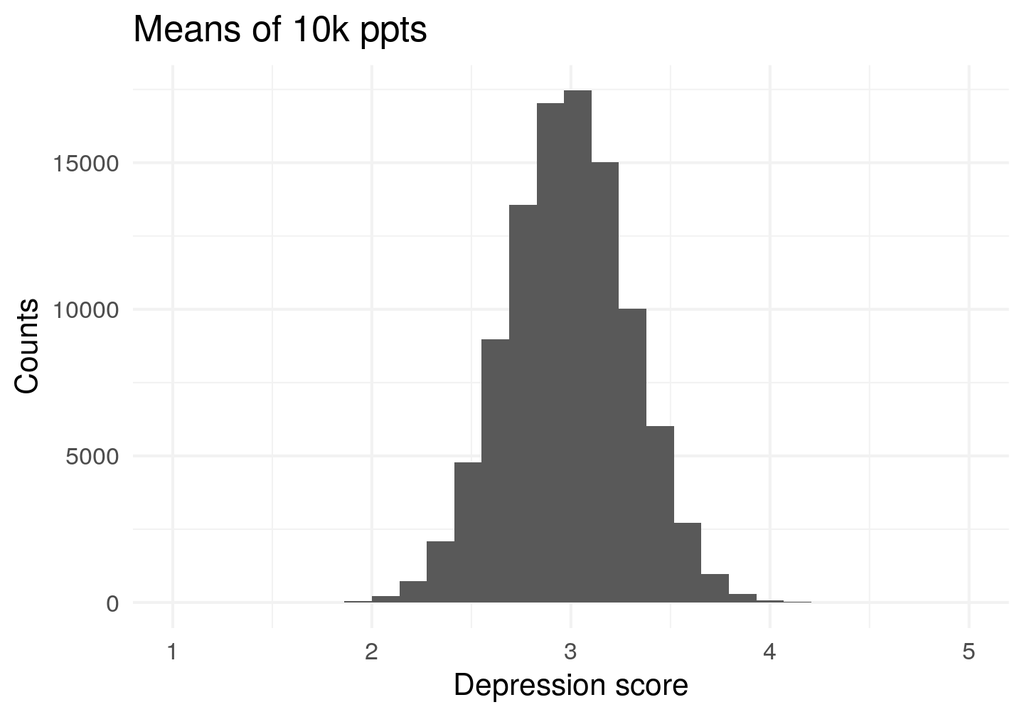